# Spatial data science: just asking questions

David O’Sullivan

University of Auckland

Paparoa Track by Phoebe Smith from [wanderlustmagazine.com](https://www.wanderlustmagazine.com/inspiration/on-the-road-again-new-zealand-west-coast-new-great-walk-paparoa-track/)

### Enough already with the *rebrandings*!

### Why *data*, not *information*?

### Why *spatial*, not *geographical*?

### What are the *implications* of any of this?

New Zealand Tūī by Jan Andersson at [ebird.org](https://ebird.org/atlasnz/species/tui1/). Tūī are known for their cheeky personalities

# What’s in a name?

### For me, SDS, like many (most?) of the rebrandings<sup>1</sup>, is about belonging

### It also signals a desire to move on from

### GIS

Image from [commons.wikimedia.org](https://commons.wikimedia.org/wiki/File:Conputer_lab_2.jpg) by ProjectManhattan

[^1]: automated cartography, spatial data handling, GIS, geographic(al) information science, spatial information theory, geocomputation, geographic data science, geomatics, geoinformatics, spatial information systems

### And to instead do *geospatial stuff*

> “But hunt for a central term that describes what all these have in common, and what do we have? Geospatial is perhaps the strongest contender, but it’s an adjective: “What do you do?” “I do geospatial. . .er. . .stuff.”<sup>1</sup>
[^2]: Goodchild MF. 2015. [Four thoughts on the future of GIS](https://www.esri.com/about/newsroom/arcwatch/four-thoughts-on-the-future-of-gis). *ArcWatch* (February).

[figure not shown]

# Why ‘data’?

## What is/are data?

### Not ‘raw’ or ‘given’

### Not ‘facts’ (although data is/are made)

### Not information

### Not knowledge

### Not wisdom

Rodin’s *Le Penseur* cropped from [commons.wikimedia.org](https://commons.wikimedia.org/wiki/File:Le_Penseur_in_the_Jardin_du_Mus%C3%A9e_Rodin,_Paris_14_June_2015.jpg) by Douglas O’Brien

## A proposition

### **knowledge** ≫ **information** ≫ **data**

> What does it mean to retreat from knowledge to information? Knowledge is about ideas, about putting ideas together into integrated systems of thought we call disciplines. Information is about facts, about separating out a particular feature of a situation and recording it as an autonomous observation. (Taylor 1990<sup>1</sup>, page 212)
[^3]: Taylor PJ. 1990. Editorial comment GKS. *Political Geography Quarterly* **9**(3) 211–212. See also: Goodchild MF. 1991. Just the facts. *Political Geography Quarterly* **10**(4) 335–337.

## A provocation

### Could a GeoAI be (or become) a GKS?

Spoiler: I don’t think so

# Why ‘spatial’?

## Another proposition

### **geography** ≠ **geometry**

## The geo-atom

> the fundamental element of geographical information is the tuple
> $$T=\langle x,y,z_1,z_2\ldots z_n\rangle$$

Goodchild in Frank AU and MF Goodchild 1990. Two perspectives on geographical data modelling. *NCGIA Technical Reports (9011)*. Available at [escholarship.org](https://escholarship.org/uc/item/7zn585sw).

### Here’s Alfred North Whitehead:

> [a]s soon as you have settled […] what you mean by a definite place in space-time, you can adequately state the relation of a particular material body to space-time by saying that it is just there, in that place; and, so far as simple location is concerned, there is nothing more to be said on the subject (Whitehead [1925] 1967<sup>1</sup>, page 50)
[^4]: Whitehead AN. [1925] 1967. *Science and the Modern World: Lowell Lectures, 1925*. The Free Press.

## So… what *is* geographical?

[figure not shown]

[figure not shown]

[figure not shown]

[figure not shown]

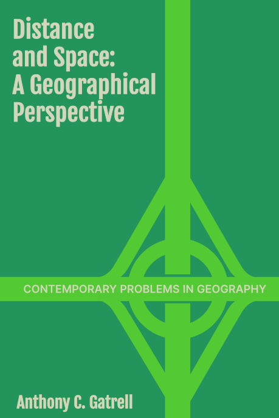

[figure not shown]

### 😁 Your one stop shop →

### … in geography

### There aren’t many general free-floating concepts

### Our computational constructs must be grounded in domain-relevant ideas

### Some ‘portable’ (e.g., neighbourhood, scale); others less so (e.g., home range)

# Implications

### In *Computing Geographically*<sup>1</sup> I wrote that,

> giscience […] should *really* “never again be quite the comfortable retreat for the technically minded” (Goodchild, 2006<sup>2</sup>, page 687), *which it remains*, in spite of the best efforts of critical GIS scholars. (page 254, emphasis added)
[^5]: O’Sullivan D. 2024. *Computing Geographically: Bridging Giscience and Geography*. Guilford Press, New York.
[^6]: Goodchild MF. 2006. [GIScience ten years after Ground Truth](https://dx.doi.org/10.1111/j.1467-9671.2006.01022.x). *Transactions in GIS* **10**(5), 687-692

## Making connections

Thatcher JE, LR Bergmann and D O’Sullivan. 2016. [Searching for common ground (again)](https://escholarship.org/uc/item/8nq409qz). In *International Conference on GIScience Short Paper Proceedings* eds. JA Miller, D O’Sullivan and N Wiegand, 304–307.

## I would say this, but…

[figure not shown]

# In conclusion

### Enough already with the *rebrandings*!

### Why *data*, not *information*?

### Why *spatial*, not *geographical*?

### What are the *implications* of any of this?

Pīwakawaka (fantail) by Phoebe Smith from [wanderlustmagazine.com](https://www.wanderlustmagazine.com/inspiration/on-the-road-again-new-zealand-west-coast-new-great-walk-paparoa-track/). The pīwakawaka is known for its inquisitive friendliness.

## Thank you!

[figure not shown]

dosull.github.io

[figure not shown]

Computing  
Geographically  
bonus material

Image source [flickr.com](https://www.flickr.com/photos/volvob12b/9112326315/) by [Bernard Spragg](https://www.flickr.com/photos/volvob12b/)